# The EM algorithm for the admixture model

In this exercise we will open up the black box of `ADMIXTURE`/`NGSadmix` and implement the EM algorithm that estimates the admixture proportions **Q** and the ancestral allele frequencies **F**.

**Learning objectives**

- Be able to write up the likelihood of the admixture model
- Understand which quantity is the hidden (latent) variable in the model
- Be able to perform the E-step: the probability that an allele copy comes from a given ancestral population
- Be able to perform the M-step: the update of **Q** and **F**
- Implement a complete EM algorithm and see it converge to the maximum likelihood estimate

The exercise follows the slides from the admixture lecture. Everything is done in R on simulated data, so you can see how close the estimates get to the truth.

**The data.** Simulated in the notebook: 50 individuals and 2000 SNPs from 2 ancestral populations () — 20 from each population and 10 admixed — so the estimated admixture proportions can be compared with the true ones.

# 1. The model

We have individuals typed at SNPs and we assume there are ancestral populations.

- is an matrix. is the proportion of individual 's genome that comes from population , so .
- is an matrix. is the frequency of the (say) `A` allele at SNP in population . On the slides this is sometimes called ("Phrequencies").

[figure not shown]

- is the observed genotype: the number of `A` alleles that individual carries at SNP . We write the two allele copies as and , so

[figure not shown]

  .

Each allele copy is drawn in two steps

1. pick an ancestral population with probability

[figure not shown]

2. draw the allele from that population with probability

[figure not shown]

So the probability that one allele copy of individual at SNP is an `A` allele is the **individual allele frequency**

[figure not shown]

**Questions**

- Why do we sum over ? Which variable are we summing out?
- Assume Hardy-Weinberg equilibrium *within* the individual. Write up

[figure not shown]

  using .
- With , individuals and SNPs, how many parameters does the model have? (the general answer is on the slides: , but how many are *free*?)

Let us redo the small calculation from the slides. Individual has admixture proportions

[figure not shown]

and at SNP the frequency of the `T` allele is in population 1 and in population 2. The individual has the genotype `TT`.

```
Qi <- c(0.4, 0.6)   # admixture proportions of the individual
Fj <- c(0.7, 0.2)   # frequency of the T allele in pop 1 and pop 2

## individual allele frequency: probability that ONE allele copy is a T
h <- sum(Qi * Fj)
cat("h = p(allele = T) =", h, "\n")

## the genotype is TT, i.e. both allele copies are T
cat("p(G = TT) =", h^2, "\n")
```

```
h = p(allele = T) = 0.4
p(G = TT) = 0.16
```

- Recalculate by hand and check that you get the same.
- What is (one T and one C allele)?
- What would be if the individual was not admixed but came entirely from population 2?

# 2. The likelihood

Assuming that the SNPs are independent and that the two allele copies of an individual are independent (HWE), the likelihood of the whole data set is (slide *EM algorithm - reformulate the likelihood*)

[figure not shown]

and by introducing the hidden ancestry state of each allele copy

[figure not shown]

## The likelihood written with the individual allele frequency

Once we have summed out the hidden ancestry state, each of the two allele copies of individual at SNP is simply an `A` allele with probability

[figure not shown]

, independently of each other (that is the HWE assumption). Two independent draws with the same success probability is exactly a **binomial distribution** with trials

[figure not shown]

so

[figure not shown]

which written out for the three possible genotypes is just HWE with the frequency

genotype

[figure not shown]

0

no `A` alleles

1

heterozygote

[figure not shown]

2

two `A` alleles

Note that this is the *usual* HWE formula - the only new thing is that every individual has its **own** allele frequency at each SNP, given by its admixture proportions.

Taking the logarithm of the binomial probability and summing over all individuals and SNPs gives the log likelihood

[figure not shown]

The constant is

[figure not shown]

. It does not depend on or , so we can drop it - it shifts the log likelihood up or down but does not move the maximum.

Read the two terms as counts: is the number of `A` alleles the individual carries and is the number of other alleles, each weighted by the log probability of drawing it.

**Questions**

- Which term in the sum

[figure not shown]

  is and which is ?
- Write up

[figure not shown]

  for a heterozygote and check that it matches the formula above.
- Why are we allowed to throw away the binomial coefficient ?
- Why is *not* the allele frequency of a population, but of an individual?
- Why is there no analytical solution (i.e. why can we not just set the derivative to zero and solve)?

## Simulate some data

We simulate individuals and SNPs from populations. The first 20 individuals are from population 1, the last 20 from population 2 and the 10 in the middle are admixed. The ancestral frequencies are drawn with a Balding-Nichols model with , i.e. the two populations are fairly differentiated.

```
set.seed(3)
N <- 50      # individuals
M <- 2000    # SNPs
K <- 2       # ancestral populations
Fst <- 0.15  # how differentiated the two populations are

## true ancestral allele frequencies (M x K)
anc <- runif(M, 0.05, 0.95)                        # frequency in the common ancestor
bn <- function(p, Fst) rbeta(length(p), p*(1-Fst)/Fst, (1-p)*(1-Fst)/Fst)
Ftrue <- cbind(bn(anc, Fst), bn(anc, Fst))

## true admixture proportions (N x K)
q1 <- c(rep(1, 20), seq(0.9, 0.1, length.out = 10), rep(0, 20))
Qtrue <- cbind(q1, 1 - q1)

## simulate the genotypes: G_ij ~ Binomial(2, h_ij)
Htrue <- Qtrue %*% t(Ftrue)                        # N x M individual allele frequencies
G <- matrix(rbinom(N*M, 2, Htrue), nrow = N, ncol = M)

cat("dimension of the genotype matrix:", dim(G), "\n")
print(G[1:5, 1:8])
```

```
dimension of the genotype matrix: 50 2000
     [,1] [,2] [,3] [,4] [,5] [,6] [,7] [,8]
[1,]    0    2    0    0    1    2    0    0
[2,]    2    2    0    0    2    2    0    1
[3,]    0    2    1    0    0    1    0    1
[4,]    1    2    1    1    2    2    1    0
[5,]    0    2    0    0    2    2    0    0
```

```
## the true admixture proportions we are trying to recover
barplot(t(Qtrue), col = c("steelblue", "red"), border = NA, space = 0,
        xlab = "individual", ylab = "admixture proportion", main = "TRUE Q")
```

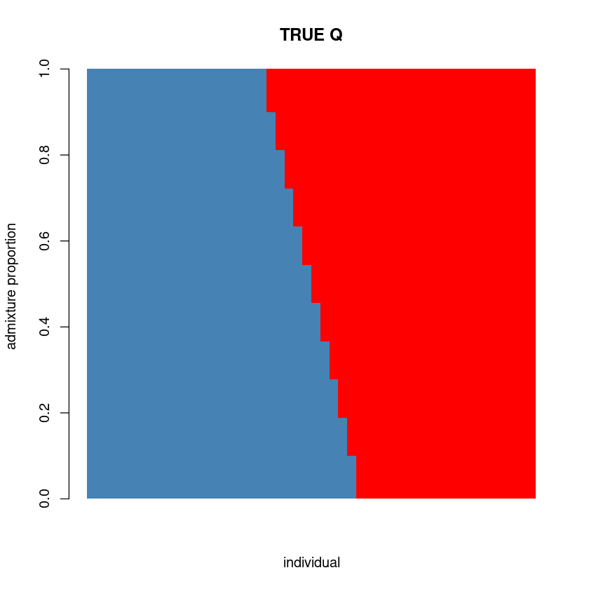

Now the log likelihood function. Note that it only needs `Q` and `F` through the individual allele frequencies `H`.

```
logLike <- function(Q, F, G){
  H <- Q %*% t(F)                                  # N x M individual allele frequencies
  sum( G * log(H) + (2 - G) * log(1 - H) )
}

cat("log likelihood at the true parameters:", logLike(Qtrue, Ftrue, G), "\n")
cat("log likelihood at a random guess     :",
    logLike(matrix(0.5, N, K), matrix(0.5, M, K), G), "\n")
```

```
log likelihood at the true parameters: -95140.69
log likelihood at a random guess     : -138629.4
```

- Identify , and

[figure not shown]

  in the code.
- Why is the likelihood higher for the true parameters?

# 3. The E-step

The EM algorithm works because we can introduce the hidden variable - the ancestral population that an allele copy came from. From the slides (*EM algorithm - Fits our problem*) the E-step is the posterior probability of the hidden state

[figure not shown]

which by Bayes' formula is

[figure not shown]

where is shorthand for " if the allele copy is an `A` allele and if it is not".

Let us reproduce the numbers on the slide. Individual 1 has

[figure not shown]

and at SNP 1 the frequency of the `A` allele is in population 1 and in population 2. The genotype of the individual is `AT`, i.e. one allele copy is an `A` and the other is a `T`.

```
Qi <- c(0.2, 0.8)    # admixture proportions of individual 1
Fj <- c(0.2, 0.3)    # frequency of the A allele at SNP 1 in the two populations

## allele copy 1 is an A allele
pA <- Fj * Qi / sum(Fj * Qi)
## allele copy 2 is a T allele  (probability 1-F of being drawn from each population)
pT <- (1 - Fj) * Qi / sum((1 - Fj) * Qi)

cat("p(ancestry | the A allele) :", round(pA, 2), "\n")
cat("p(ancestry | the T allele) :", round(pT, 2), "\n")
```

```
p(ancestry | the A allele) : 0.14 0.86
p(ancestry | the T allele) : 0.22 0.78
```

- Compare with the table on the slides (0.14/0.86 and 0.22/0.78). Do you get the same?
- The individual has 80% ancestry from population 2 but the `A` allele is assigned to population 2 with 86%. Why is it higher than 80%?
- What happens to the posterior if the two populations have the same allele frequency ()? Try it in the code above. What does that tell you about which SNPs carry information about ancestry?
- What happens if the individual is not admixed, ?

### Run the cell below to take the quiz

```
from jupyterquiz import display_quiz

display_quiz("https://raw.githubusercontent.com/popgenDK/courses/main/current_exercises/em_algorithms/quiz/admixture_em_model.json")
```

# 4. The M-step

In the M-step we update the parameters using the posterior probabilities as if they were observed counts. From the slides

[figure not shown]

For our model it is convenient to define, for each individual , SNP and population , the **expected number of allele copies coming from population** . Since a genotype contains `A` alleles and other alleles

[figure not shown]

is the expected number of `A` alleles from population and the expected number of non-`A` alleles from population .

The updates are then just the corresponding frequencies

[figure not shown]

**Questions**

- is updated by summing over SNPs while is updated by summing over individuals. Explain why.
- Why do we divide by in the update of ?
- Convince yourself that

[figure not shown]

  automatically. (hint: what is ?)
- Compare the two updates with the simple allele frequency estimator you have seen before: "expected number of A alleles divided by expected number of alleles". Where is the difference?

## A note on `outer()`

The code below is written with matrices so that it runs fast. The only trick used is `outer()`, which is the **outer product** of two vectors: it multiplies every element of the first vector with every element of the second

[figure not shown]

so element of `outer(x, y)` is simply . With (a vector of length ) and (a vector of length ) we get the matrix that holds for **all** individuals and SNPs at once - the contribution of population to the individual allele frequency.

The individual allele frequencies themselves are the matrix product , i.e.

[figure not shown]

, which in R is `Q %*% t(F)`. In other words

[figure not shown]

The matrix product sums over the populations, while `outer` keeps one population at a time - which is exactly what we need in the E-step, where we want the ancestry probabilities separately for each population.

```
x <- c(1, 2, 3)        # imagine this is Q[,k]  (N = 3 individuals)
y <- c(10, 20)         # imagine this is F[,k]  (M = 2 SNPs)

outer(x, y)            # 3 x 2 matrix with element (i,j) = x_i * y_j
x %*% t(y)             # exactly the same thing written as a matrix product

## and the sum over the K populations is the matrix product Q %*% t(F)
H1 <- Qtrue %*% t(Ftrue)
H2 <- outer(Qtrue[,1], Ftrue[,1]) + outer(Qtrue[,2], Ftrue[,2])
cat("are the two ways of getting H identical?", all.equal(H1, H2), "\n")
```

A matrix: 3 × 2 of type dbl

| 10 | 20 |
| --- | --- |
| 20 | 40 |
| 30 | 60 |

A matrix: 3 × 2 of type dbl

| 10 | 20 |
| --- | --- |
| 20 | 40 |
| 30 | 60 |

```
are the two ways of getting H identical? TRUE
```

- Check by hand that `outer(c(1,2,3), c(10,20))` gives what you expect.
- Why does `H` have dimensions and not or ?

```
## one full EM step: returns the updated Q and F
emStep <- function(Q, F, G){
  N <- nrow(Q); M <- nrow(F); K <- ncol(Q)
  H <- Q %*% t(F)                                   # N x M individual allele frequencies

  Qnew <- matrix(0, N, K)
  Fnum <- matrix(0, M, K)     # numerator   sum_i a_ijk
  Fden <- matrix(0, M, K)     # denominator sum_i (a_ijk + b_ijk)

  for(k in 1:K){
    ## E-step: expected number of allele copies from population k
    a <- G       * outer(Q[,k],     F[,k])  / H       # the A alleles
    b <- (2 - G) * outer(Q[,k], 1 - F[,k])  / (1 - H) # the other alleles

    ## M-step
    Qnew[,k] <- rowSums(a + b) / (2 * M)              # sum over SNPs
    Fnum[,k] <- colSums(a)                            # sum over individuals
    Fden[,k] <- colSums(a + b)
  }
  ## keep the frequencies away from 0 and 1 so log(0) does not appear in the likelihood
  bound <- function(x, e = 1e-5) pmin(pmax(x, e), 1 - e)
  list(Q = Qnew, F = bound(Fnum / Fden))
}
```

- Find the E-step and the M-step in the function.
- `outer(Q[,k], F[,k])` is the matrix with entries and `H` is the matrix with entries . Which part of the formula is `outer(Q[,k], F[,k]) / H`?
- Why is `a` multiplied by `G` and `b` by `2-G`?
- `rowSums` sums over SNPs and `colSums` over individuals. Which one belongs to and which to ?

# 5. The complete EM algorithm

An EM algorithm is just: start at a random guess, do E- and M-steps until the likelihood stops increasing.

```
admixEM <- function(G, K, maxIter = 500, tol = 0.1, seed = 1){
  set.seed(seed)
  N <- nrow(G); M <- ncol(G)

  ## random starting point
  Q <- matrix(runif(N*K), N, K); Q <- Q / rowSums(Q)   # rows must sum to one
  F <- matrix(runif(M*K, 0.1, 0.9), M, K)

  ll <- logLike(Q, F, G)
  llTrace <- ll
  for(iter in 1:maxIter){
    par <- emStep(Q, F, G)
    Q <- par$Q
    F <- par$F
    llNew <- logLike(Q, F, G)
    llTrace <- c(llTrace, llNew)
    if(abs(llNew - ll) < tol){                         # converged: the likelihood barely moves
      cat("converged after", iter, "iterations\n")
      break
    }
    ll <- llNew
  }
  if(iter == maxIter)
    cat("stopped after", maxIter, "iterations without reaching the tolerance\n")
  list(Q = Q, F = F, logLike = ll, trace = llTrace, iterations = iter)
}

res <- admixEM(G, K = 2)
cat("log likelihood of the estimate:", res$logLike, "\n")
cat("log likelihood of the truth   :", logLike(Qtrue, Ftrue, G), "\n")
```

```
converged after 288 iterations
log likelihood of the estimate: -93055.86
log likelihood of the truth   : -95140.69
```

```
## the likelihood must increase in every single iteration
plot(res$trace, type = "l", xlab = "EM iteration", ylab = "log likelihood")
abline(h = logLike(Qtrue, Ftrue, G), col = "red", lty = 2)
legend("bottomright", c("EM", "true parameters"), col = c("black", "red"), lty = c(1, 2))
```

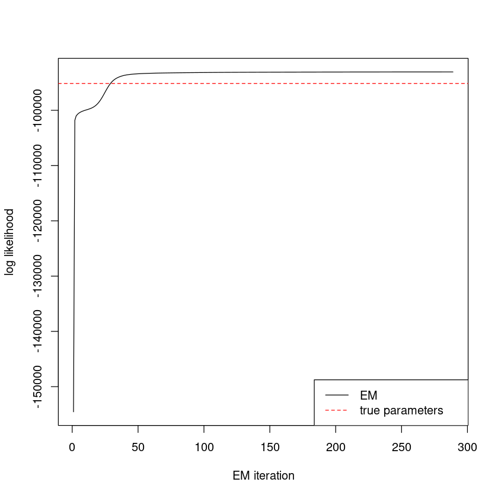

- Does the likelihood increase in every iteration? It is guaranteed to by the EM algorithm.
- The estimate can have a **higher** likelihood than the true parameters. Is that a bug? (hint: how many parameters are we estimating compared to how much data we have?)
- Look at the curve: the likelihood jumps a lot in the first iterations and then creeps. The EM algorithm is very stable but converges slowly, so we stop when the log likelihood changes by less than `tol = 0.1` between two iterations rather than waiting for it to stop changing completely. Real implementations use accelerated versions of the EM algorithm (`ADMIXTURE` and `NGSadmix` both do). Try `plot(admixEM(G, K = 2, maxIter = 20)$Q[,1], res$Q[,1])` - are 20 iterations enough?
- Try a much stricter tolerance, e.g. `admixEM(G, K = 2, tol = 1e-6)`. How many more iterations does it use, and does the estimate of change much?

```
par(mfrow = c(2,1), mar = c(4,4,2,1))
barplot(t(Qtrue), col = c("steelblue","red"), border = NA, space = 0,
        ylab = "proportion", main = "TRUE Q")
barplot(t(res$Q),  col = c("steelblue","red"), border = NA, space = 0,
        ylab = "proportion", xlab = "individual", main = "ESTIMATED Q")
```

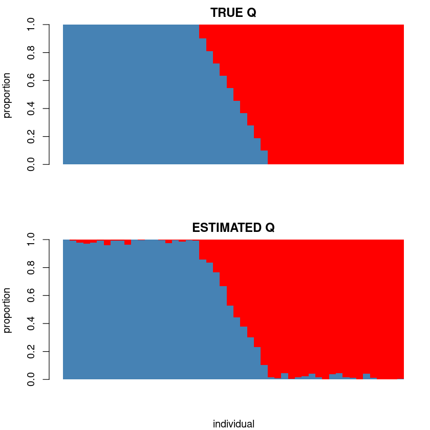

```
par(mfrow = c(1,2))
plot(Qtrue[,1], res$Q[,1], xlab = "true Q (pop 1)", ylab = "estimated Q (pop 1)",
     main = "admixture proportions"); abline(0, 1, col = "red")
plot(Ftrue[,1], res$F[,1], xlab = "true F (pop 1)", ylab = "estimated F (pop 1)",
     main = "allele frequencies", pch = 16, cex = 0.4, col = "#00000044")
abline(0, 1, col = "red")
```

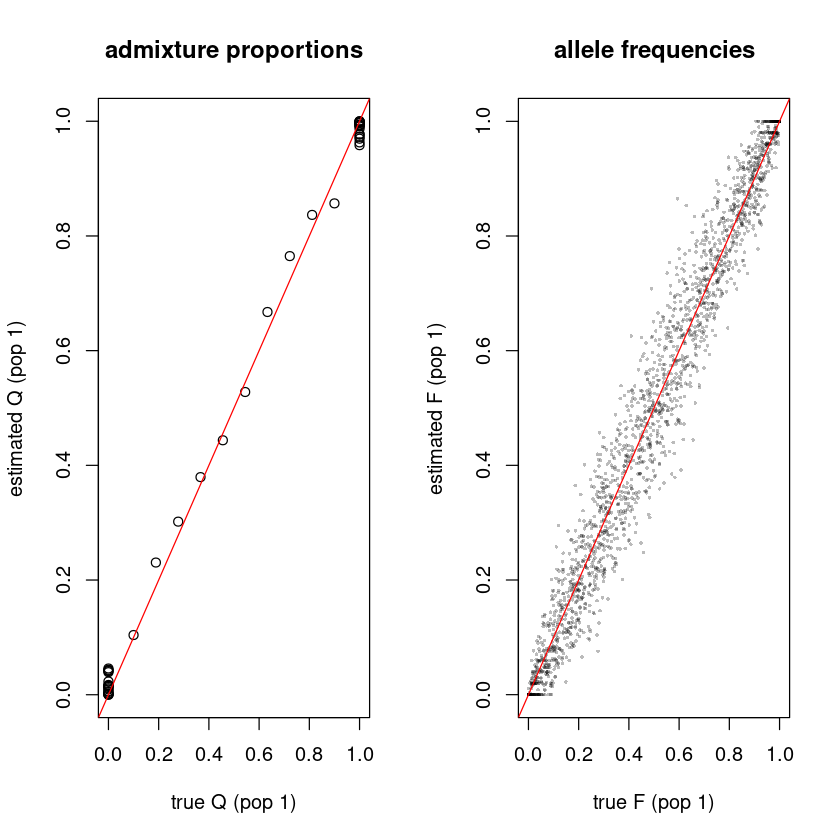

- How well are the admixture proportions estimated? And the allele frequencies?
- It can happen that the colours are swapped, so that estimated population 1 corresponds to true population 2 and the points fall on the *other* diagonal. Why can the EM algorithm not know which population is "population 1"? This is called **label switching**.
- has parameters and has . Which of the two do you expect to be estimated most precisely, and why?

# 6. Things to be aware of

## Local optima

The likelihood surface of the admixture model has multiple maxima. The EM algorithm is only guaranteed to climb to *a* maximum - not the global one. Therefore both `ADMIXTURE` and `NGSadmix` are run several times with different starting points and the run with the highest likelihood is kept.

```
## run the EM 5 times from different random starting points
ll <- sapply(1:5, function(s) admixEM(G, K = 2, seed = s)$logLike)
print(ll)
```

```
converged after 288 iterations
converged after 285 iterations
converged after 282 iterations
converged after 273 iterations
converged after 294 iterations
[1] -93055.86 -93055.78 -93055.72 -93055.75 -93055.76
```

- Do all the runs end up at the same likelihood?
- If two runs have very different likelihoods, which one would you keep?
- In practice you would run it ~10 times and sort them by likelihood. If the top 5 have nearly the same likelihood you keep the top one, otherwise you run 10 more. Why is this a reasonable strategy?

## Choice of K

Try to run the algorithm with on data that was simulated with .

```
res3 <- admixEM(G, K = 3)
cat("K=2 log likelihood:", res$logLike,  "\n")
cat("K=3 log likelihood:", res3$logLike, "\n")

barplot(t(res3$Q), col = c("steelblue","red","darkgreen"), border = NA, space = 0,
        ylab = "proportion", xlab = "individual", main = "ESTIMATED Q with K=3")
```

```
K=2 log likelihood: -93055.86
K=3 log likelihood: -91984.67
```

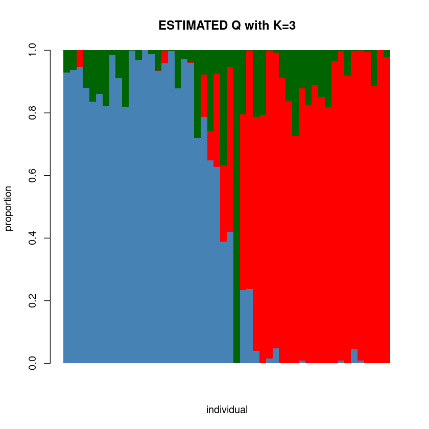

- Is the likelihood with higher or lower than with ? Will it always be that way?
- Can you use the likelihood to choose ?
- What does the third population look like - does it correspond to anything real?

### Run the cell below to take the quiz

```
from jupyterquiz import display_quiz

display_quiz("https://raw.githubusercontent.com/popgenDK/courses/main/current_exercises/em_algorithms/quiz/admixture_em_practice.json")
```

# Bonus: from genotypes to genotype likelihoods (NGSadmix)

With low depth NGS data we do not know the genotypes. Instead of the called genotype we have the genotype likelihoods

[figure not shown]

for the three possible genotypes, and the likelihood becomes (slide *NGSadmix*)

[figure not shown]

where

[figure not shown]

is the HWE probability using the individual allele frequency . The genotype is now *also* a hidden variable, so the E-step gets one extra layer: first we get the posterior probability of the genotype, and from that the expected number of `A` alleles

[figure not shown]

and then the M-step is **exactly the same as before** with replaced by .

```
## simulate genotype likelihoods from 2x sequencing depth with an error rate of 1%
simGL <- function(G, depth = 2, e = 0.01){
  N <- nrow(G); M <- ncol(G)
  d <- matrix(rpois(N*M, depth), N, M)                 # number of reads
  pA <- c(1-e, 0.5, e)[G+1]                            # p(read is A | genotype)
  nA <- matrix(rbinom(N*M, d, pA), N, M)               # reads with the A allele
  ## genotype likelihoods p(X|G) for G = 0,1,2 copies of the A allele
  list(GL0 = dbinom(nA, d, e), GL1 = dbinom(nA, d, 0.5), GL2 = dbinom(nA, d, 1-e))
}

emStepGL <- function(Q, F, GL){
  N <- nrow(Q); M <- nrow(F); K <- ncol(Q)
  H <- Q %*% t(F)

  ## E-step part 1: posterior probability of the genotype (HWE prior with freq H)
  p0 <- GL$GL0 * (1-H)^2
  p1 <- GL$GL1 * 2*H*(1-H)
  p2 <- GL$GL2 * H^2
  tot <- p0 + p1 + p2
  EG <- (p1 + 2*p2) / tot                              # expected number of A alleles

  ## E-step part 2 + M-step: identical to before, with G replaced by EG
  Qnew <- matrix(0, N, K); Fnum <- matrix(0, M, K); Fden <- matrix(0, M, K)
  for(k in 1:K){
    a <- EG       * outer(Q[,k],     F[,k]) / H
    b <- (2 - EG) * outer(Q[,k], 1 - F[,k]) / (1 - H)
    Qnew[,k] <- rowSums(a + b) / (2 * M)
    Fnum[,k] <- colSums(a)
    Fden[,k] <- colSums(a + b)
  }
  bound <- function(x, e = 1e-5) pmin(pmax(x, e), 1 - e)
  list(Q = Qnew, F = bound(Fnum / Fden))
}

set.seed(7)
GL <- simGL(G, depth = 2)

## run the EM with the genotype likelihoods
set.seed(1)
Q <- matrix(runif(N*K), N, K); Q <- Q / rowSums(Q)
F <- matrix(runif(M*K, 0.1, 0.9), M, K)
for(i in 1:200){
  par <- emStepGL(Q, F, GL); Q <- par$Q; F <- par$F
}

par(mfrow = c(1,2))
barplot(t(Qtrue), col = c("steelblue","red"), border = NA, space = 0, main = "TRUE Q")
barplot(t(Q),     col = c("steelblue","red"), border = NA, space = 0, main = "NGSadmix-like Q (2x depth)")
```

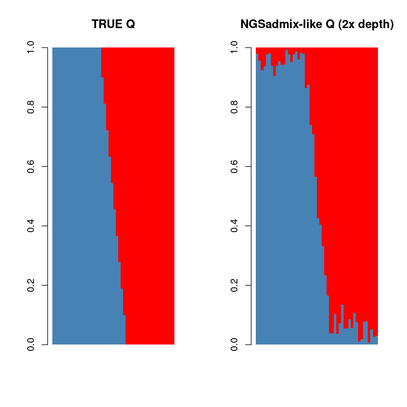

- Compare with the result from the called genotypes. How much do we lose by having only 2x depth?
- Where in `emStepGL` is the genotype likelihood

[figure not shown]

  and where is the prior

[figure not shown]

  ?
- If you set the depth very high, `emStepGL` should give the same answer as `emStep`. Why?
- Why is it a bad idea to call the genotypes first and then run the normal `ADMIXTURE` algorithm on low depth data?